# Subgroup Identification Analysis

Applications to consistency analyses in MRCTs

Author

Larry Leon

```r
knitr::opts_chunk$set(echo = TRUE, message=FALSE, warning=FALSE)

options(warn = -1)

rm(list=ls())

library(tinytex)
library(ggplot2)
library(table1)

library(gt)

# test these packages
# just for testing any conflicts
# library(tidyverse)
# library(plyr)
# library(dplyr)
# library(glmnet)

library(survival)
library(data.table)
library(randomForest)
library(grf)
library(policytree)
library(DiagrammeR)

library(grid)
library(forestploter)
library(randomizr)

# library(devtools)
# install_github("larry-leon/weightedsurv", force = TRUE)
# install_github("larry-leon/forestsearch", force = TRUE)


library(forestsearch)
library(weightedsurv)

#help(forestsearch)
#help(generate_aft_dgm_flex)
```

# 1 Summary

We evaluate the potential for utilizing subgroup analyses for enhancing regional consistency analyses in oncology multi-regional clinical trials (MRCTs). We consider a setting where asia pacific (AP) countries consist of approximately $15-20\%$ of a global trial and the criteria for consistency is a positive point estimate (Cox model hazard-ratio $< 1.0$) while the global trial meets statistical significance.

Suppose the following –

**ITT meets statistical significance but the AP regional analysis appears problematic (hazard-ratio estimate $\approx 1.0$)**

Can a subgroup with enhanced benefit be identified in the non-AP population which then translates to the AP population?

That is, suppose there exists a subgroup ${\cal G}$ such that the treatment affect is more pronounced and (standard) Cox model analyses based on the ${\cal G}$ subgroup of AP (AP$({\cal G})$, say) enables meeting consistency.

We assume Cox model analyses are the primary analysis where only the treatment arm is included as a covariate (with or without stratification by randomization factors).

While there are a plethora of subgroup identification approaches available we consider the *forestSearch* approach, León et al. (2024), which was developed for identifying strong subgroup treatment effects (i.e., strong HTEs).

We consider three objectives: (A) Identify a subgroup with the largest detrimental effect (*harm*, say) defined in terms of the largest hazard-ratio estimate exceeding a clinical threshold in favor of control (e.g., $\hat\beta \geq \log(0.90)$); (B) Identify the *smallest* subgroup with a hazard-ratio estimate indicative of *harm* (e.g., $\hat\beta \geq \log(0.90)$); and (C) Identify the *largest* subgroup with strong benefit (e.g., $\hat\beta \leq \log(0.60)$). These objectives are related with the overarching goal of identifying a subgroup with enhanced benefit; In (A) and (B) we identify a subgroup indicative of *harm*, $\hat{\cal H}$ say, in which case the complementary subgroup (${\hat{\cal H}}^{c}:= {\hat{\cal G}}$) may be generally beneficial. Whereas in (C) we are more directly *targeting* a strong (clinically compelling) beneficial subgroup effect.

Throughout this note R code is provided and illustrated based on real trial data (subject-level baseline characteristics are fixed at their observed quantities). Our hope is that these notes can serve as a framework for future trial planning as well as for simulating from study data to understand the operating characteristics for teams and external discussions.

A diagram illustrating the general flow follows.

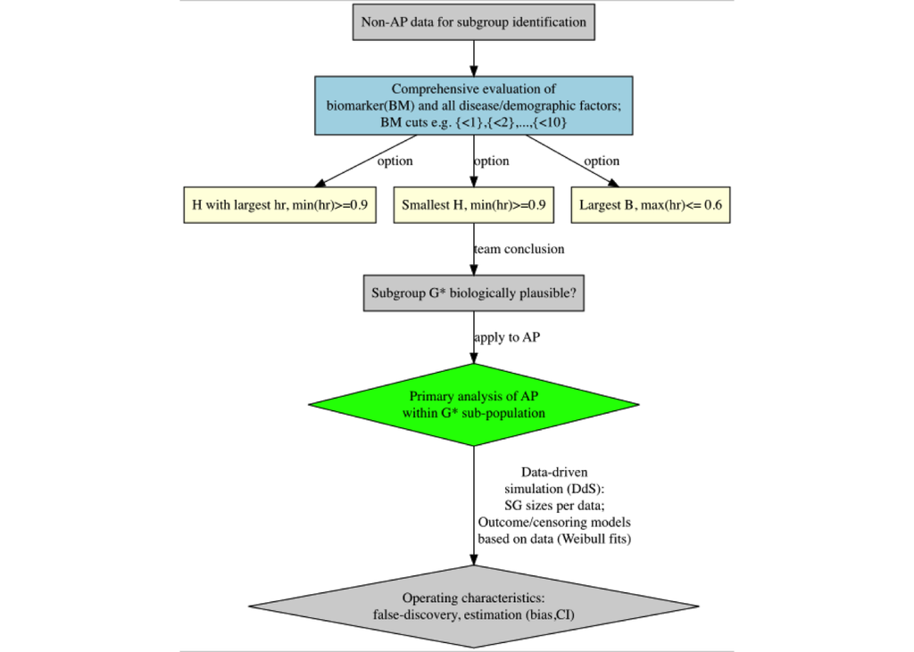

Subgroup identification analysis based on non-AP data to identify subgroups of marked benefit in AP. Operating characteristics evaluates whole process starting from analysis option

```r
library(png)
library(grid)
img <- readPNG('MRCT-Flow.png')
grid.raster(img)
```

# 2 Weibull AFT/Cox model with biomarker effects

## 2.1 Brief Review

For the Weibull distribution with shape parameter $\nu$ and scale parameter $\theta$ the density, cdf, survival, hazard and cumulative hazard functions are:
$$\begin{eqnarray*}
f(t) &=& \nu \theta^{-\nu}t^{\nu-1}\exp(-(t/\theta)^{\nu}), \cr F(t)
&=& \int_{0}^{t}\nu \theta^{-\nu}s^{\nu-1}\exp(-(s/\theta)^{\nu})ds
\cr &=& \int_{0}^{(t/\theta)^{\nu}}e^{-w}dw \cr & &
(w=(s/\theta)^{\nu},dw=\nu s^{\nu-1}\theta^{-\nu}ds) \cr
&=&1-\exp(-(t/\theta)^{\nu}), \cr S(t) &=& \exp(-(t/\theta)^{\nu}),
\cr \lambda(t)&=&\nu \theta^{-\nu}t^{\nu-1}, \cr \Lambda(t) &=&
-\log(S(t))=(t/\theta)^{\nu}.
\end{eqnarray*}$$
Note that here we define the density to correspond with R’s definition. For shape parameter $\nu \in (0,1)$ the hazard is strictly decreasing in $t \geq 0$, whereas for $\nu >1$ the hazard is strictly increasing in $t \geq 0$.

*Note*: $\Lambda(T) \sim E(1)$

The cumulative hazard function $\Lambda(\cdot)$ evaluated at $T$, $\Lambda(T)$, as a random variable has cdf
$$\eqalign{ \Pr(\Lambda(T) \leq t) &=\Pr(-\log(1-F(T)) \leq t) =\Pr(1-F(T) \geq e^{-t}) \cr
&=\Pr(T \leq F^{-1}(1-e^{-t})) =F(F^{-1}(1-e^{-t})) = 1-e^{-t}, \cr}$$
which is the CDF of the exponential distribution, $E(1)$ (say).

In the following we use

$$\begin{equation}
\tag{1}
\Lambda(T) \sim E(1)
\end{equation}$$
to represent the Weibull regression model as an AFT model which is also a Cox model.

Now, $\Lambda(T)=(T/\theta)^{\nu}$ and write $Q=-\log(S(T))=\Lambda(T)=(T/\theta)^{\nu}$, where from (1), $Q \sim E(1)$. That is $\log(Q)=\nu(\log(T)-\log(\theta))$ can be expressed as

$$\begin{equation}
\tag{2}
\log(T)=\log(\theta)+ \tau \log(Q) := \log(\theta) + \tau \epsilon,
\end{equation}$$
where $\tau=1/\nu$ and it is easy to show that $\epsilon=\log(Q)$ has the ``extreme value’’ distribution with density $f_{\epsilon}(x)=\exp(x-e^{x})$ for $x \in {\cal R}$. Here the range of $\log(T) \in {\cal R}$ is un-restricted. The *survReg* routine uses the parameterization $(2)$ and therefore estimates $\log(\theta)$ and $\tau=1/\nu$.

To incorporate covariates $L$ (say) we specify
$$\lambda(t;L)=\big(\nu \theta^{-\nu}t^{\nu-1} \big) \exp(L'\beta)
:= \lambda_{0}(t)\exp(L'\beta),$$
where $\lambda_{0}(t)$ is the hazard, say, for $T_{0} \sim \hbox{Weibull}(\nu,\theta)$. This is a special case of the proportional hazards model. The chf (conditional chf with covariate vector $L$) is $\Lambda(t;Z)=(t/\theta)^{\nu}\exp(L'\beta)$ so that analogous to above this leads to the representation

$$\begin{equation}
\tag{3}
\log(T) =\log(\theta)+\tau[-L'\beta+\epsilon] =\log(\theta)+L'\gamma + \tau \epsilon,
\end{equation}$$
where $\gamma=-\tau\beta$, with $\tau$ and $\epsilon$ defined in (2). R *survReg* uses this AFT parameterization so that the estimated components of $\gamma$, $\gamma_{p}$ say, are that of $-\tau\beta_{p}$ for $p=1,\ldots,m$ ($m$ is dimension of $\beta$).

When fitting the AFT model (3) via suvreg we therefore transform parameters $\hat\gamma$ to the Weibull hazard-ratio parameterization (2) via

$$\begin{equation}
\tag{4}
\hat\beta = -\hat\gamma / \hat{\tau}.
\end{equation}$$

As an illustration we compare the *survReg* model fits for the case-study dataset. The following table below compares the Weibull *survReg* model fits with covariates Treat and Ecog1 (Ecog = 1 vs 0) where components of $\hat\gamma$ from model (3) are calculated according to *survReg* and $\hat\beta$ are formed via (4). In the table below Weibull estimates of $\hat\beta$ are compared to Cox model versions.

```r
# case-study example
# Draw sample from synthetic dataset (n=2,000)
dfsynth <- read.table("data/dfsynthetic.csv", header=TRUE, sep=",")
# Consider the "full" dataset
# will sample trials (eg, n=500) below
df.case <- dfsynth

# Draw sample of n=500
# ndraw <- 500
# set.seed(8316951)
# id_draw <- sample(1:nrow(dfsynth), ndraw)
# df.case <- dfsynth[id_draw,]
#names(df.case)
```

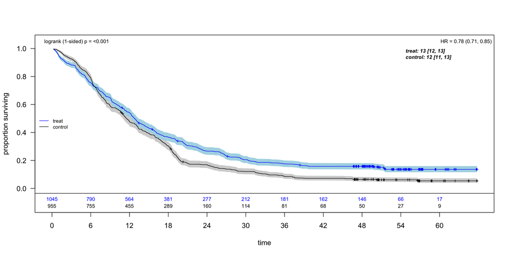

```r
# Original data

dfc <- df_counting(
  df = df.case,
  by.risk = 6,
  tte.name = "tte",
  event.name = "event",
  treat.name = "treat"
)

plot_weighted_km(dfc, conf.int = TRUE, show.logrank = TRUE, ymax = 1.05)
```

```r
# Comparing Weibull vs Cox with case-study where outcomes are artifical
# This is just for illustration to show conversion of Weibull parameters from
# AFT regression to Weibull hazard
fit.weib_ex <- survreg(Surv(tte,pmax(event,1)) ~ treat + ecog, dist='weibull', data=df.case)
tauhat <- fit.weib_ex$scale
# convert (treat,ecog1) regression parms to Weibull hazard-ratio
bhat.weib <- -(1)*coef(fit.weib_ex)[c(2,3)]/tauhat
# Compare to Cox
fit.cox_ex <- coxph(Surv(tte,pmax(event,1)) ~ treat + ecog, data=df.case)
res <- cbind(bhat.weib,coef(fit.cox_ex))
res <- as.data.frame(res)
colnames(res)<-c("Weibull","Cox")
res |> gt() |>
fmt_number(columns=1:2,decimals=6) |>
tab_header(title="Comparing Weibull to Cox hazard ratio estimates",
subtitle="Case-study dataset with artificial outcomes")
```

Comparing Weibull to Cox hazard ratio estimates

Case-study dataset with artificial outcomes

| Weibull | Cox |
| --- | --- |
| −0.258118 | −0.221810 |
| 0.332700 | 0.337246 |

## 2.2 Biomarker effects with spline model

We now outline how potential outcomes are simulated according to parameters fit to the case-study dataset but with parameters specified to induce biomarker effects. That is, causal treatment effects (on log(hazard-ratio) scale) that follow a spline model according to patterns where biomarker effects increase with biomarker levels; Including various degrees of limited treatment effects for low biomarker levels.

We first consider a Weibull model with treatment and a single biomarker covariate $Z$ where we write the linear predictor of the Cox model $L'\beta$ (say) as

$$\begin{equation}
\tag{5}
L'\beta := \beta_{1}\hbox{Treat} + \beta_{2}\hbox{Z} + \beta_{3}\hbox{Z}\hbox{Treat} + \beta_{4}(\hbox{Z}-k)I(\hbox{Z}>k) + \beta_{5}(\hbox{Z}-k)I(\hbox{Z}>k)\hbox{Treat}.
\end{equation}$$

Following the potential-outcome approach let $l_{x,z}$ denote subject’s hazard-function “had they followed treatment regimen $Treat=x$ while having biomarker level $Z=z$”. That is, for subject with biomarker level $Z=z$ we can simulate their survival outcomes under both treatment ($x=1$) and control ($x=0$) conditions. Let $\beta^{0} = (\beta_{1}^{0},\ldots,\beta_{5}^{0})'$ denote the true coefficients and denote the hazard function as

$$\lambda_{x,z}(t) = \lambda_{0}(t)\exp(l_{x,z}), \quad \hbox{say}.$$

Writing

$$\begin{equation}
l_{x,z} = \beta^{0}_{1}x + \beta^{0}_{2}z + \beta^{0}_{3}zx + \beta^{0}_{4}(z-k)I(z>k) +
\beta^{0}_{5}(z-k)I(z>k)x,
\end{equation}$$
the log of the hazard ratio for biomarker level $z$ under treatment ($x=1$) relative to control ($x=0$) is given by

$$\begin{equation}
\tag{6}
\psi^{0}(z) := \log(\lambda_{1,z}(t)/\lambda_{0,z}(t)) = \beta^{0}_{1} + \beta^{0}_{3}z + \beta^{0}_{5}(z-k)I(z>k).
\end{equation}$$

## 2.3 Causal log-hazard-ratio

The log(hazard-ratio) for biomarker level $z$ is a linear function of $z$ with a change-point (in slope) at $z=k$ given by

$$\begin{eqnarray*}
\psi^{0}(z) &=& \beta^{0}_{1} + \beta^{0}_{3}z, \quad \hbox{for} \ z \leq k, \cr
&=& \beta^{0}_{1} + \beta^{0}_{3}z + \beta^{0}_{5}(z-k), \quad \hbox{for} \ z > k.
\end{eqnarray*}$$

Log hazard-ratio parameters $(\beta^{0}_{1},\beta^{0}_{3},\beta^{0}_{5})$ can be chosen to generate “treatment effect patterns” by specifying $\psi^{0}(z)$ values at $z=0$, $z=k$, and $z=\zeta$ for $\zeta > k$. For specified $\psi^{0}(0)$, $\psi^{0}(k)$, and $\psi^{0}(\zeta)$ we have

$$\begin{eqnarray}
\beta^{0}_{1} &=& \psi^{0}(0), \cr
\beta^{0}_{3} &=& {(\psi^{0}(k) - \beta^{0}_{1}) \over k}, \cr
\beta^{0}_{5} &=& {(\psi^{0}(\zeta) - \beta^{0}_{1} - \beta^{0}_{3}\zeta) \over (\zeta -k)}.
\end{eqnarray}$$

The function *get_dgm_stratified* generates $\psi^{0}(z)$ according to desired “biomarker treatment effect patterns” as follows.

- Let $X$ and $Z$ denote the treatment and biomarker variables in the case-study dataset and for specified $k$, form the covariates $L:=(X,Z,ZX,(Z-k)I(Z>k),(Z-k)I(Z>k)X))$;
- Fit the Weibull model (recall on AFT scale) to get $\log(\hat\theta)$, $\hat\tau=1/\hat{\nu}$, and $\hat\gamma$ corresponding to $L$;
- $\hat\gamma$ is in terms of the AFT parameterization given by model (3)
- Next transform to the Weibull (Cox) log hazard-ratio parameterization (4): $\hat\beta = -\hat\gamma/\hat\tau$
- Set “true” parameters $\theta^{0}=\hat\theta$, and $\tau^{0}=\hat\tau$
- Initialize the “true” parameter $\beta^{0} = \hat\beta$ and re-define parameters 1, 3, and 5 in order to satisfy specified $\psi^{0}(0)$, $\psi^{0}(k)$, and $\psi^{0}(\zeta)$: $\beta^{0}[1] = \psi^{0}(0)$, $\beta^{0}[3] = (\psi^{0}(k) - \beta^{0}[1])/k$, and $\beta^{0}[5] = (\psi^{0}(\zeta) - \beta^{0}[1] - \beta^{0}[3]\zeta)/(\zeta -k)$;
- Form corresponding $\gamma^{0}= -\beta^{0}\tau^{0}$
- For simulations we use the AFT parameterization (3) to generate $\log(T)$ outcomes according to $\log(T) = \log(\theta^{0}) + L'\gamma^{0} + \tau^{0}\epsilon$ where recall $\epsilon$ has the ``extreme value’’ distribution.

The inputs of the *get_dgm_stratified* function are:

- The case-study dataset (“df”)
- “knot”=$k$, “zeta”=$\zeta$, and “log.hrs”= ($\psi^{0}(0),\psi^{0}(k),\psi^{0}(\zeta))$
- Note that *get_dgm_stratified* allows for outcomes to follow a stratified Weibull (Cox) models in which case the log(hazard-ratio) effects will depend on the strata, “strata_tte”, where the default is non-stratified (“strata_tte=NULL”)
- If stratified the $\tau$ parameters and hence $\gamma^{0}$ depend on the strata
- If stratified, then to simplify, the $\gamma^{0}$ effects are calculated based on the median of the $\tau^{0}$’s ($\tau^{0}=\tau_{med}$, say).

## 2.5 Including prognostic factors $W$

We extend the model to include a baseline prognostic factor $W$ within $L$ (effect parameter $\beta^{0}_{w}$) where

$$\begin{equation}
l_{x,z,w} = \beta^{0}_{1}x + \beta^{0}_{2}z + \beta^{0}_{3}zx + \beta^{0}_{4}(z-k)I(z>k) +
\beta^{0}_{5}(z-k)I(z>k)x + \beta^{0}_{w}w.
\end{equation}$$

Note that defining $m(1,z,w)$ [$m(0,z,w)$)] as the conditional expected value of $\log(T)$ with treatment set to experimental [control] given biomarker level $Z=z$ and $W=w$

$$\psi^{0}(z,w) = \{m(0,z,w)-m(1,z,w)\}/\tau$$
which corresponds to the difference in the (true) means of the potential outcomes under experimental and control conditions ($\log(T[0,z,w]$ versus $\log(T[1,z,w]$, say)

# 3 Specifying biomarker treatment effects

## 3.1 Average hazard ratios (AHRs)

We define the *biomarker average hazard ratio (AHR)* as the expected value of $\psi^{0}(\cdot)$ across “increasing biomarker” sub-populations. For example, $\hbox{AHR}(2^{+})$ represents the AHR for subjects with biomarker values $\geq 2$ via

$$\begin{equation}
\tag{6}
\hbox{AHR}(z^{+}):= \exp\left\{E_{Z \geq z} \psi^{0}(Z) \right\};
\end{equation}$$

With the opposite direction – across “decreasing biomarker” sub-populations

$$\begin{equation}
\tag{7}
\hbox{AHR}(z^{-}):= \exp\left\{E_{Z \leq z} \psi^{0}(Z) \right\}.
\end{equation}$$

Here the expectations are over the distribution of $Z$, however if there is a prognostic factor $W$ then the expectations are over $(Z,W)$. In our calculations we calculate empirical averages.

## 3.2 Controlled direct-effect (CDE) versions (Aalen, Cook, and Røysland (2015))

Averaging across hazard ratios: Define the hazard (omitting baseline hazard) $\theta^{x}(z,w) = \exp(l(x,z,w))$ setting treatment to $X=x$ given $Z=z$ and $W=w$. Aalen et al. (Aalen, Cook, and Røysland (2015)) define the controlled direct-effect (CDE) as the ratio of the expected hazards. Here we consider the above cumulative versions (omitting possible dependence on $W$). Let $\bar\theta^{x}(z+) = E_{Z \geq z}\theta^{x}(Z)$ for $x=0,1$, and define

$$\hbox{CDE}(z^{+}):= \bar\theta^{1}(z+)/\bar\theta^{0}(z+), \quad \hbox{and} \quad \hbox{CDE}(z^{-}):= \bar\theta^{1}(z-)/\bar\theta^{0}(z-)$$

## 3.3 Compare ‘AHR’ versions under various biomarker specifications

```r
# Outcome model is NON-stratified (strata_tte=NULL)
# PH

# Create AP region flag
df.case$AP <- df.case$region_asia

# Spline biomarker effects (based on "bm" spline)

dgm_spline <- generate_aft_dgm_flex(
  data = df.case,
  continuous_vars = c("age", "bm"),
  factor_vars = c("male", "histology", "prior_treat","AP"),
  set_beta_spec = list(set_var = c("z_AP"), beta_var = -log(5)),
  outcome_var = "tte",
  event_var = "event",
  treatment_var = "treat",
  cens_type = "uniform",
  subgroup_vars = NULL,
  subgroup_cuts = NULL,
  model = "alt",
  spline_spec = list(
    var = "z_bm",  # Use original variable name (or "z_er" if transformed)
    knot = 5,
    zeta = 10,
    log_hrs = log(c(2, 1.25, 0.5))  # HR varies with ER
  ),
  k_inter = 0.0,  # Amplify or turn-off (=0) subgroup per subgroup_vars effect?
  verbose = TRUE
)
```

```
Added 6 unprocessed variables: entrytime, strat, ecog, region_other, region_asia, pid

=== Spline Constraint Applied ===
Target log(HR) at z_bm = 0: 0.693
Target log(HR) at z_bm = knot ( 5 ): 0.223
Target log(HR) at z_bm = zeta ( 10 ): -0.693
k_treat multiplier: 1

=== Model Parameters (AFT with Spline, log(T)) ===
Intercept (mu): 3.339
Scale (tau): 0.93
Spline variable: z_bm
  Knot: 5
  Zeta: 10
Treatment effect at z_bm = 0: -0.644
Treatment slope before knot: 0.087
Treatment slope change after knot: 0.083

Overall subgroup in super-population (all conditions met):
  Proportion: 0

=== Hazard Ratios (super popln) ===
Overall HR: 0.668
Causal AHR: 0.657
```

```r
# dgm_spline <- generate_aft_dgm_flex(
#   data = df.case,
#   continuous_vars = c("bm"),
#   factor_vars = c("AP"),
#   set_beta_spec = list(set_var = c("z_AP"), beta_var = -log(4)),
#   outcome_var = "tte",
#   event_var = "event",
#   treatment_var = "treat",
#   subgroup_vars = NULL,
#   subgroup_cuts = NULL,
#   model = "alt",
#   spline_spec = list(
#     var = "z_bm",  # Use original variable name (or "z_er" if transformed)
#     knot = 2,
#     zeta = 5,
#     log_hrs = log(c(2.5, 1.0, 0.5))  # HR varies with ER
#   ),
#   k_inter = 0.0,  # Amplify or turn-off (=0) subgroup per subgroup_vars effect?
#   verbose = TRUE
# )


# Examine beta = log(hr) parameters

dgm_spline$model_params$b0
```

```
        treat         z_age          z_bm        z_male   z_histology
  0.693147181   0.003462212   0.141636734  -0.160194086  -0.068185915
z_prior_treat          z_AP    z_bm_treat        z_bm_k  z_bm_k_treat
  0.288535254  -1.609437912  -0.094000726  -0.180252561  -0.089257421
```

```r
cat("AP region parmeter = -log(5)?", c(dgm_spline$model_params$b0["z_AP"],-log(5)),"\n")
```

```
AP region parmeter = -log(5)? -1.609438 -1.609438
```

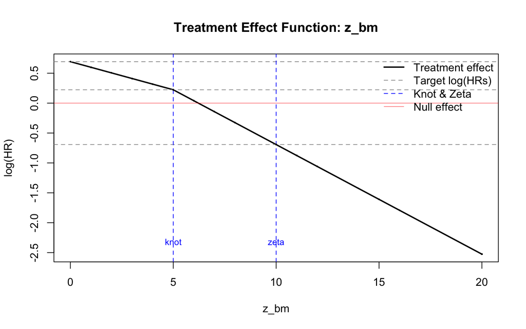

```r
# Plot the spline effect
plot_spline_treatment_effect(dgm_spline)
```

```
=====================================
Cox AHR/CDE Analysis
=====================================
Sample size: 5000
Events: 4466
Treatment allocation: 2355 2645
Biomarker range: 0 20
CDE variables available: TRUE
-------------------------------------

Step 1: Fitting Cox spline model...

=== Z Variable Summary ===
Range: 0 20
Quantiles (75%, 80%, 90%): 11 15 20
Prediction grid: 21 points from 0 to 20

=== Primary Cox Model ===
Treatment log(HR): -0.202
Treatment HR: 0.817

=== Spline Model ===
Number of parameters: 7
Treatment main effect: 1.289

Step 2: Calculating AHR and CDE metrics...
Calculating Controlled Direct Effects (CDEs)...

Step 3: Calculating subgroup statistics...

Subgroup Summary:
      Subgroup    n n_pct events AHR_po   CDE
1 Questionable 2978  59.6   2728  1.517 1.485
2    Recommend 2022  40.4   1738  0.191 0.312
3      Overall 5000 100.0   4466  0.657 1.048

Optimal cutpoint (z_bm >= 7) defines 'Recommend' subgroup

Step 4: Creating visualizations...
```

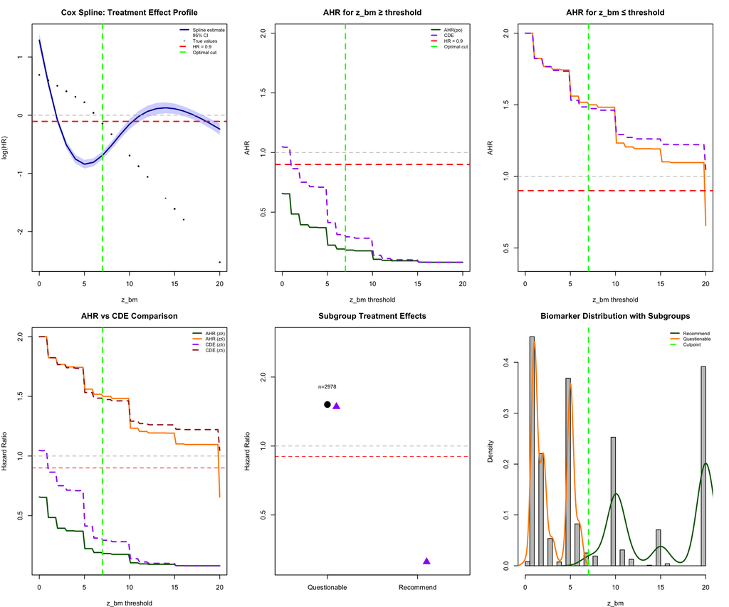

```
=====================================
Analysis Complete
=====================================
Optimal cutpoint: 7
Recommend subgroup size: 2022 ( 40.4 %)
AHR (Recommend): 0.191
CDE (Recommend): 0.312
=====================================
```

```r
 results <- cox_ahr_cde_analysis(
   df = dgm_spline$df_super,
   tte_name = "y", event_name = "event", treat_name = "treat",
   z_name = "z_bm",
   hr_threshold = 0.9,
   plot_style = "grid"
 )
```

```r
 # Access specific results
 print(results$subgroup_stats)
```

```
      Subgroup    n n_pct events AHR_po   CDE
1 Questionable 2978  59.6   2728  1.517 1.485
2    Recommend 2022  40.4   1738  0.191 0.312
3      Overall 5000 100.0   4466  0.657 1.048
```

```r
 print(results$optimal_cutpoint)
```

```
[1] 7
```

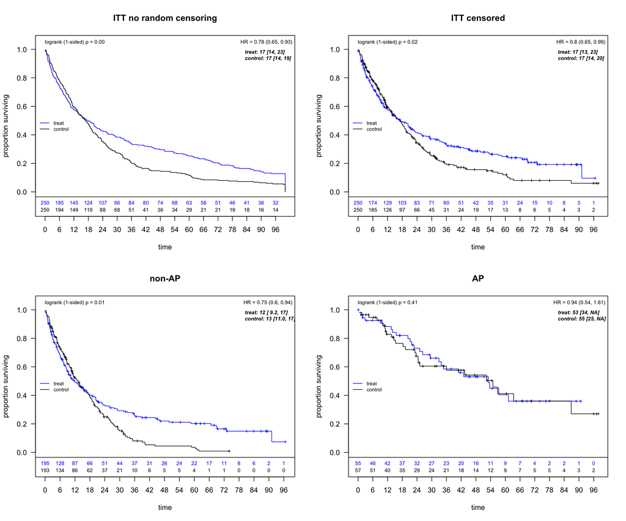

```r
# Simulate data

df_example <- simulate_from_dgm(
  dgm = dgm_spline,
  n = 500,
  rand_ratio = 1,
  draw_treatment = TRUE,
  max_follow = 100,
  seed = 1235
)

# ITT
dfc <- df_counting(
  df = df_example,
  by.risk = 6,
  tte.name = "y_sim",
  event.name = "event_sim",
  treat.name = "treat_sim"
)

# No censoring
# Except by max_follow

df_example$t_true <- pmin(df_example$t_true, 100)

df_example$event_mod <- ifelse(df_example$t_true <= 100,1,0)

dfideal <- df_counting(
  df = df_example,
  by.risk = 6,
  tte.name = "t_true",
  event.name = "event_mod",
  treat.name = "treat_sim"
)


df_nonAP <- subset(df_example, z_AP == 0)
df_AP <- subset(df_example, z_AP == 1)


# non-AP
dfc0 <- df_counting(
  df = df_nonAP,
  by.risk = 6,
  tte.name = "y_sim",
  event.name = "event_sim",
  treat.name = "treat_sim"
)

# AP
dfc1 <- df_counting(
  df = df_AP,
  by.risk = 6,
  tte.name = "y_sim",
  event.name = "event_sim",
  treat.name = "treat_sim"
)


par(mfrow=c(2,2))

plot_weighted_km(dfideal, conf.int = FALSE, show.logrank = TRUE, ymax = 1.05)
title("ITT no random censoring")

plot_weighted_km(dfc, conf.int = FALSE, show.logrank = TRUE, ymax = 1.05)
title("ITT censored")

plot_weighted_km(dfc0, conf.int = FALSE, show.logrank = TRUE, ymax = 1.05)
title("non-AP")

plot_weighted_km(dfc1, conf.int = FALSE, show.logrank = TRUE, ymax = 1.05)
title("AP")
```

```
=== Z Variable Summary ===
Range: 0 20
Quantiles (75%, 80%, 90%): 10 15 20
Prediction grid: 21 points from 0 to 20

=== Primary Cox Model ===
Treatment log(HR): -0.218
Treatment HR: 0.804

=== Spline Model ===
Number of parameters: 7
Treatment main effect: -0.065
```

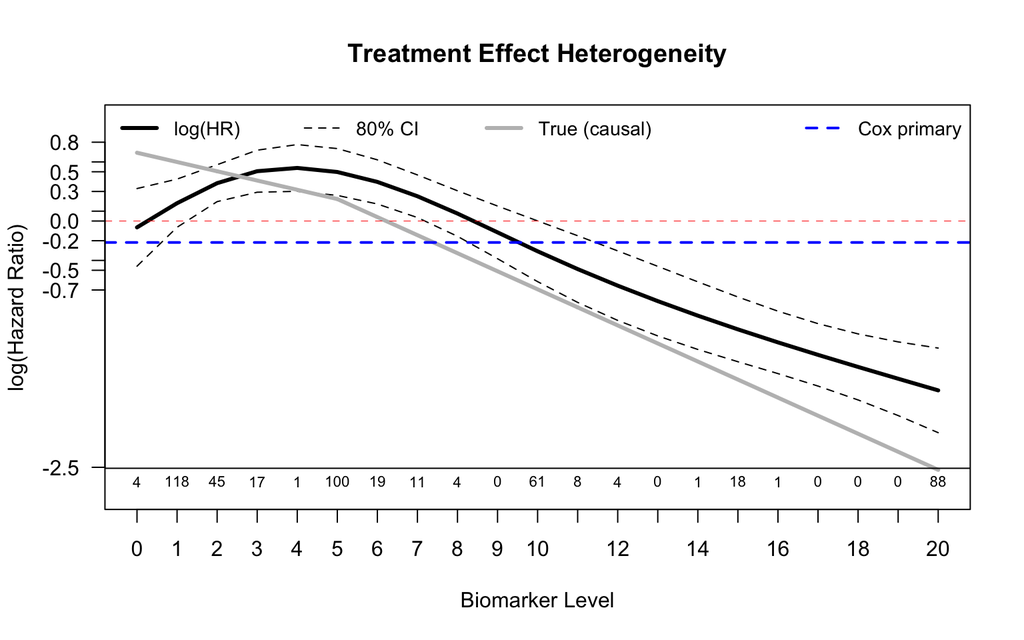

```r
result <- cox_cs_fit(
  df = df_example, tte_name = "y_sim", event_name ="event_sim", treat_name = "treat_sim",
  truebeta_name = "loghr_po",
  z_name = "z_bm", z_by = 1, z_window = 0.5,
  alpha = 0.20,
  plot_params = list(
    xlab = "Biomarker Level",
    main_title = "Treatment Effect Heterogeneity"
  )
)
```

- Here we simulated a study according to the biomarker effects described above
- Summarize the non-AP and AP populations
- Apply subgroup identification procedures to the non-AP data and apply to AP

# 4 Subgroup identification criteria: Options for targeting subgroup effects

```
GRF stage for cut selection with dmin,tau= 12 0.6
tau, maxdepth = 37.1051 2
   leaf.node control.mean control.size control.se depth
1          2         6.84       226.00       1.44     1
2          3       -11.55       162.00       1.90     1
11         4         7.82       208.00       1.48     2
4          7       -12.56       157.00       1.88     2

Selected subgroup:
   leaf.node control.mean control.size control.se depth
11         4         7.82       208.00       1.48     2

GRF subgroup found
Terminating node at max.diff (sg.harm.id):
[1] "z_age <= 76"

All splits:
[1] "z_bm <= 5"   "z_age <= 76" "z_age <= 36"
# of continuous/categorical characteristics 2 5
Continuous characteristics: z_age z_bm
Categorical characteristics: z_male ecog z_histology z_prior_treat strat
## Prior to lasso: z_age z_bm
#### Lasso selection results
7 x 1 sparse Matrix of class "dgCMatrix"
                        s0
z_age          0.009648792
z_bm          -0.074285256
z_male        -0.238786199
ecog          -0.126597190
z_histology    .
z_prior_treat  0.201281801
strat          .
Cox-LASSO selected: z_age z_bm z_male ecog z_prior_treat
Cox-LASSO not selected: z_histology strat
### End Lasso selection
## After lasso: z_age z_bm
Default cuts included from Lasso: z_age <= mean(z_age) z_age <= median(z_age) z_age <= qlow(z_age) z_age <= qhigh(z_age) z_bm <= mean(z_bm) z_bm <= median(z_bm) z_bm <= qlow(z_bm) z_bm <= qhigh(z_bm)
Categorical after Lasso: z_male ecog z_prior_treat
Factors per GRF: z_bm <= 5 z_age <= 76 z_age <= 36
Initial GRF cuts included z_bm <= 5 z_age <= 76 z_age <= 36
```

[output cut: 29 more lines]

```
10   z_age <= 52    q10  0.0207
6      z_bm <= 1     q6  0.0195
14        z_male    q14  0.0141
2    z_age <= 76     q2  0.0003
3    z_age <= 36     q3  0.0000
5      z_bm <= 0     q5  0.0000
Number of possible configurations (<= maxk): maxk = 1 , # combinations = 32
Events criteria: control >= 12 , treatment >= 12
Subgroup search completed in 0 minutes
Found 6 subgroup candidate(s)
# of candidate subgroups (meeting all criteria) = 6
# of unique initial candidates: 6
# Restricting to top stop_Kgroups = 30
# of candidates restricted to 'top K': 6
Using parallel processing: callr with 100 workers
```

```
Consistency met!
# of splits = 1000
**** Subgroup, % Consistency Met= {z_age <= 52} 0.91
Consistency met!
# of splits = 1000
**** Subgroup, % Consistency Met= {z_bm <= 1} 1
Consistency met!
# of splits = 1000
**** Subgroup, % Consistency Met= {z_bm <= 2} 1
Consistency met!
# of splits = 1000
**** Subgroup, % Consistency Met= {z_bm <= 5} 1
Consistency met!
# of splits = 1000
**** Subgroup, % Consistency Met= {z_bm <= 7.5} 1
Consistency met!
# of splits = 1000
**** Subgroup, % Consistency Met= {z_bm <= 10} 1
```

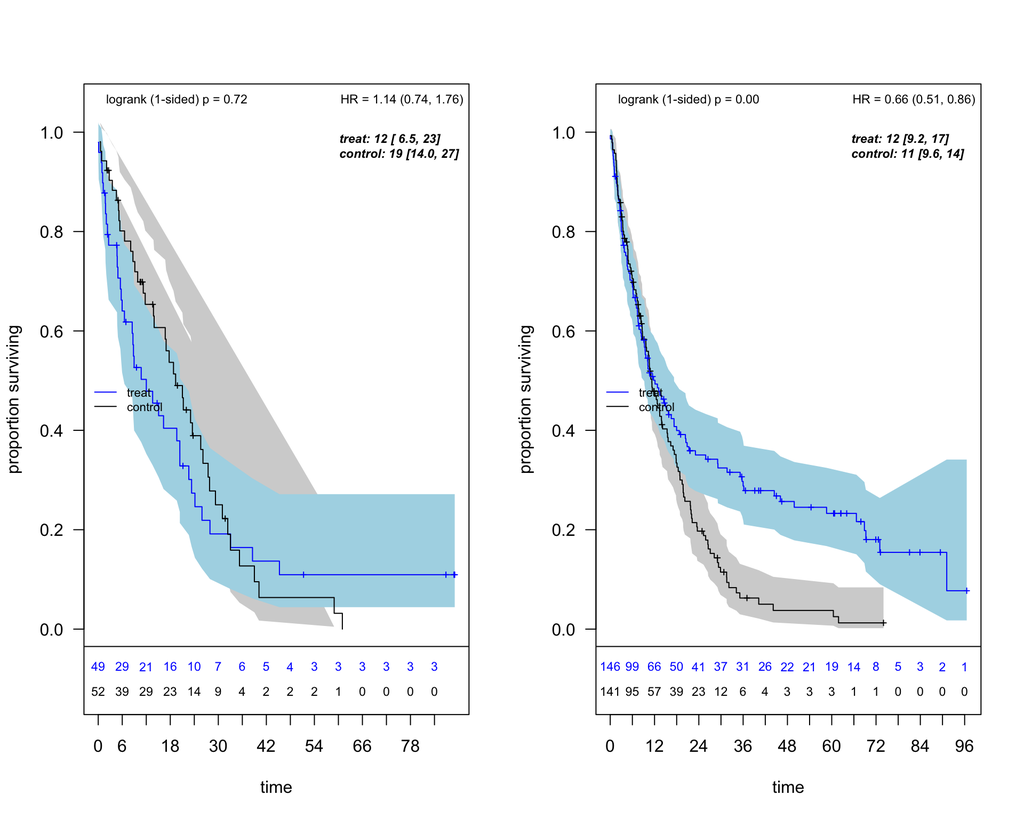

```
*** Subgroup found: {z_age <= 52}
% consistency criteria met= 0.91
SG focus= minSG
Subgroup Consistency Minutes= 0.056
Subgroup found (FS) with sg_focus='minSG'
Selected subgroup: {z_age <= 52}
Minutes forestsearch overall = 0.06
```

```
   user  system elapsed
 14.825   1.170   3.623
```

```r
confounders.name <- c("z_age","z_bm","z_male","ecog","z_histology","z_prior_treat","strat")

dfa <- as.data.frame(df_nonAP)

# Setup parallel processing
library(doFuture)
library(doRNG)

registerDoFuture()
registerDoRNG()


system.time({fs <- forestsearch(dfa,  confounders.name=confounders.name,
                                outcome.name = "y_sim", treat.name = "treat_sim", event.name = "event_sim", id.name = "id",
                                potentialOutcome.name = "loghr_po",
                                df.test = as.data.frame(df_AP),
                                flag_harm.name = NULL,
                                hr.threshold = 0.9, hr.consistency = 0.80, pconsistency.threshold = 0.80,
                                sg_focus = "minSG", max_subgroups_search = 30,
                                showten_subgroups = TRUE, details=TRUE,
                                conf_force = c("z_age <= 65", "z_bm <= 0", "z_bm <= 1", "z_bm <= 2","z_bm <= 5"),
                                cut_type = "default", use_grf = TRUE, plot.grf = TRUE, use_lasso = TRUE,
                                maxk = 1, n.min = 60, d0.min = 12, d1.min = 12,
                                plot.sg = TRUE, by.risk = 6,
                                parallel_args = list(plan="callr", workers = 100, show_message = TRUE)
)
})
```

```r
plan("sequential")



res_tabs <- sg_tables(fs, ndecimals = 3)

res_tabs$sg10_out
```

**Identified Subgroups**

Single-factor subgroups (maxk=1)

| Factor | N | Events | E₁ | HR | P<sub>cons</sub> |
| --- | --- | --- | --- | --- | --- |
| {z_age <= 52} | 101 | 79 | 38 | 1.140 | 0.910 |
| {z_bm <= 1} | 102 | 87 | 34 | 1.686 | 1.000 |
| {z_bm <= 2} | 141 | 119 | 55 | 1.811 | 1.000 |
| {z_bm <= 5} | 226 | 197 | 95 | 2.023 | 1.000 |
| {z_bm <= 7.5} | 246 | 214 | 103 | 1.884 | 1.000 |
| {z_bm <= 10} | 292 | 257 | 127 | 1.404 | 1.000 |

**Search Configuration:** Single-factor candidates (L) = 32; Maximum combinations evaluated = 32; Search depth (maxk) = 1  
**Search Results:** Candidate subgroups found = 6; Maximum HR estimate = 2.02  
**Note:** E₁ = events in treatment arm; P<sub>cons</sub> = consistency proportion

```r
res_tabs$tab_estimates
```

**Treatment Effect Estimates**

Training data estimates

| Subgroup | n | n1 | events | m1 | m0 | RMST | HR (95% CI) | AHR(po) |
| --- | --- | --- | --- | --- | --- | --- | --- | --- |
| ITT | 388 (100.0%) | 195 (50.3%) | 307 (79.1%) | 12 | 13.4 | 8 | 0.75 (0.60, 0.94) | 0.69 |
| Questionable | 101 (26.0%) | 49 (48.5%) | 79 (78.2%) | 12 | 19.3 | -2.7 | 1.14 (0.74, 1.76) | 0.87 |
| Recommend | 287 (74.0%) | 146 (50.9%) | 228 (79.4%) | 12.1 | 11.3 | 11 | 0.66 (0.51, 0.86) | 0.64 |

```r
# Testing (AP)
res_tabs <- sg_tables(fs, ndecimals = 3, which_df = "testing", est_caption = "Testing (AP) dataset")
res_tabs$tab_estimates
```

**Treatment Effect Estimates**

Testing (AP) dataset

| Subgroup | n | n1 | events | m1 | m0 | RMST | HR (95% CI) | AHR(po) |
| --- | --- | --- | --- | --- | --- | --- | --- | --- |
| ITT | 112 (100.0%) | 55 (49.1%) | 51 (45.5%) | 53.1 | 55 | 1.3 | 0.94 (0.54, 1.61) | 0.69 |
| Questionable | 11 (9.8%) | 5 (45.5%) | 5 (45.5%) | 32.9 | 56.9 | -5.5 | 5.95 (0.81, 43.90) | 0.51 |
| Recommend | 101 (90.2%) | 50 (49.5%) | 46 (45.5%) | 53.6 | 52.4 | 4.1 | 0.83 (0.47, 1.47) | 0.71 |

```
GRF stage for cut selection with dmin,tau= 12 0.6
tau, maxdepth = 37.1051 2
   leaf.node control.mean control.size control.se depth
1          2         6.84       226.00       1.44     1
2          3       -11.55       162.00       1.90     1
11         4         7.82       208.00       1.48     2
4          7       -12.56       157.00       1.88     2

Selected subgroup:
   leaf.node control.mean control.size control.se depth
11         4         7.82       208.00       1.48     2

GRF subgroup found
Terminating node at max.diff (sg.harm.id):
[1] "z_age <= 76"

All splits:
[1] "z_bm <= 5"   "z_age <= 76" "z_age <= 36"
# of continuous/categorical characteristics 2 5
Continuous characteristics: z_age z_bm
Categorical characteristics: z_male ecog z_histology z_prior_treat strat
## Prior to lasso: z_age z_bm
#### Lasso selection results
7 x 1 sparse Matrix of class "dgCMatrix"
                        s0
z_age          0.009648792
z_bm          -0.074285256
z_male        -0.238786199
ecog          -0.126597190
z_histology    .
z_prior_treat  0.201281801
strat          .
Cox-LASSO selected: z_age z_bm z_male ecog z_prior_treat
Cox-LASSO not selected: z_histology strat
### End Lasso selection
## After lasso: z_age z_bm
Default cuts included from Lasso: z_age <= mean(z_age) z_age <= median(z_age) z_age <= qlow(z_age) z_age <= qhigh(z_age) z_bm <= mean(z_bm) z_bm <= median(z_bm) z_bm <= qlow(z_bm) z_bm <= qhigh(z_bm)
Categorical after Lasso: z_male ecog z_prior_treat
Factors per GRF: z_bm <= 5 z_age <= 76 z_age <= 36
Initial GRF cuts included z_bm <= 5 z_age <= 76 z_age <= 36
```

[output cut: 29 more lines]

```
10   z_age <= 52    q10  0.0207
6      z_bm <= 1     q6  0.0195
14        z_male    q14  0.0141
2    z_age <= 76     q2  0.0003
3    z_age <= 36     q3  0.0000
5      z_bm <= 0     q5  0.0000
Number of possible configurations (<= maxk): maxk = 1 , # combinations = 32
Events criteria: control >= 12 , treatment >= 12
Subgroup search completed in 0 minutes
Found 5 subgroup candidate(s)
# of candidate subgroups (meeting all criteria) = 5
# of unique initial candidates: 5
# Restricting to top stop_Kgroups = 30
# of candidates restricted to 'top K': 5
Using parallel processing: callr with 100 workers
```

```
Consistency met!
# of splits = 1000
**** Subgroup, % Consistency Met= {z_bm <= 1} 1
Consistency met!
# of splits = 1000
**** Subgroup, % Consistency Met= {z_bm <= 2} 1
Consistency met!
# of splits = 1000
**** Subgroup, % Consistency Met= {z_bm <= 5} 1
Consistency met!
# of splits = 1000
**** Subgroup, % Consistency Met= {z_bm <= 7.5} 1
Consistency met!
# of splits = 1000
**** Subgroup, % Consistency Met= {z_bm <= 10} 1
```

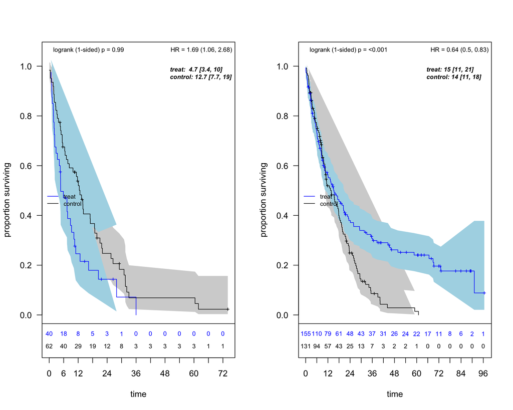

```
*** Subgroup found: {z_bm <= 1}
% consistency criteria met= 1
SG focus= minSG
Subgroup Consistency Minutes= 0.0464
Subgroup found (FS) with sg_focus='minSG'
Selected subgroup: {z_bm <= 1}
Minutes forestsearch overall = 0.05
```

```
   user  system elapsed
 12.387   0.754   3.030
```

```r
confounders.name <- c("z_age","z_bm","z_male","ecog","z_histology","z_prior_treat","strat")

dfa <- as.data.frame(df_nonAP)

# Setup parallel processing
library(doFuture)
library(doRNG)

registerDoFuture()
registerDoRNG()


system.time({fs <- forestsearch(dfa,  confounders.name=confounders.name,
                                outcome.name = "y_sim", treat.name = "treat_sim", event.name = "event_sim", id.name = "id",
                                potentialOutcome.name = "loghr_po",
                                df.test = as.data.frame(df_AP),
                                flag_harm.name = NULL,
                                hr.threshold = 1.25, hr.consistency = 0.80, pconsistency.threshold = 0.80,
                                sg_focus = "minSG", max_subgroups_search = 30,
                                showten_subgroups = TRUE, details=TRUE,
                                conf_force = c("z_age <= 65", "z_bm <= 0", "z_bm <= 1", "z_bm <= 2","z_bm <= 5"),
                                cut_type = "default", use_grf = TRUE, plot.grf = TRUE, use_lasso = TRUE,
                                maxk = 1, n.min = 60, d0.min = 12, d1.min = 12,
                                plot.sg = TRUE, by.risk = 6,
                                parallel_args = list(plan="callr", workers = 100, show_message = TRUE)
)
})
```

```r
plan("sequential")



res_tabs <- sg_tables(fs, ndecimals = 3)

res_tabs$sg10_out
```

**Identified Subgroups**

Single-factor subgroups (maxk=1)

| Factor | N | Events | E₁ | HR | P<sub>cons</sub> |
| --- | --- | --- | --- | --- | --- |
| {z_bm <= 1} | 102 | 87 | 34 | 1.686 | 1.000 |
| {z_bm <= 2} | 141 | 119 | 55 | 1.811 | 1.000 |
| {z_bm <= 5} | 226 | 197 | 95 | 2.023 | 1.000 |
| {z_bm <= 7.5} | 246 | 214 | 103 | 1.884 | 1.000 |
| {z_bm <= 10} | 292 | 257 | 127 | 1.404 | 1.000 |

**Search Configuration:** Single-factor candidates (L) = 32; Maximum combinations evaluated = 32; Search depth (maxk) = 1  
**Search Results:** Candidate subgroups found = 5; Maximum HR estimate = 2.02  
**Note:** E₁ = events in treatment arm; P<sub>cons</sub> = consistency proportion

```r
res_tabs$tab_estimates
```

**Treatment Effect Estimates**

Training data estimates

| Subgroup | n | n1 | events | m1 | m0 | RMST | HR (95% CI) | AHR(po) |
| --- | --- | --- | --- | --- | --- | --- | --- | --- |
| ITT | 388 (100.0%) | 195 (50.3%) | 307 (79.1%) | 12 | 13.4 | 8 | 0.75 (0.60, 0.94) | 0.69 |
| Questionable | 102 (26.3%) | 40 (39.2%) | 87 (85.3%) | 4.7 | 12.7 | -5.1 | 1.69 (1.06, 2.68) | 1.83 |
| Recommend | 286 (73.7%) | 155 (54.2%) | 220 (76.9%) | 15.3 | 13.8 | 8.5 | 0.64 (0.50, 0.83) | 0.49 |

```r
# Testing (AP)
res_tabs <- sg_tables(fs, ndecimals = 3, which_df = "testing", est_caption = "Testing (AP) dataset")
res_tabs$tab_estimates
```

**Treatment Effect Estimates**

Testing (AP) dataset

| Subgroup | n | n1 | events | m1 | m0 | RMST | HR (95% CI) | AHR(po) |
| --- | --- | --- | --- | --- | --- | --- | --- | --- |
| ITT | 112 (100.0%) | 55 (49.1%) | 51 (45.5%) | 53.1 | 55 | 1.3 | 0.94 (0.54, 1.61) | 0.69 |
| Questionable | 20 (17.9%) | 13 (65.0%) | 9 (45.0%) | 53.1 | 55 | 1.7 | 1.59 (0.39, 6.56) | 1.82 |
| Recommend | 92 (82.1%) | 42 (45.7%) | 42 (45.7%) | 43 | 52.4 | 1.8 | 0.92 (0.50, 1.67) | 0.55 |

## References

Aalen, O. O., R. J. Cook, and K. Røysland. 2015. “Does Cox Analysis of a Randomized Survival Study Yield a Causal Treatment Effect?” *Lifetime Data Analysis*, 579–93.

León, Larry F., Thomas Jemielita, Zifang Guo, Rachel Marceau West, and Keaven M. Anderson. 2024. “Exploratory Subgroup Identification in the Heterogeneous Cox Model: A Relatively Simple Procedure.” *Statistics in Medicine* 43 (20): 3921–42. https://doi.org/https://doi.org/10.1002/sim.10163.